# Master TIDE - Conférences Python 2020

Francis Wolinski

© 2020 Yotta Conseil

```python
# imports
import numpy as np
import pandas as pd
import matplotlib.pyplot as plt
from matplotlib import cm
import seaborn as sns
%matplotlib inline

# display options
pd.set_option("display.max_rows", 20)
```

## Analyse en composantes principales

L'analyse en composantes principales (ACP) est une procédure statistique qui utilise une transformation orthogonale pour convertir un ensemble d'observations de variables numériques potentiellement corrélées vers un ensemble de valeurs non corréelées appelées composantes principales.

Cette procédure statistique consiste à réduire le nombre de dimensions, c'est-à-dire, à représenter un jeu de données avec un nouveau jeu de dimension moindre. Si l'on choisit de réduire à 2 dimensions, il est possible de visualiser les données sur un graphique 2D.

#### Dataset

Le jeu de données provient des Nations Unies (UNCTAD) et concerne les facteurs de développement du e-commerce par pays :

- % d'individus qui utilisent internet, source : International Telecommunication Union (ITU)
- % d'individus de 15 ans et plus qui ont un compte bancaire, source : Banque Mondiale
- nombre de serveurs internet sécurisés par million d'habitants, source : Banque Mondiale
- score de fiabilité postale, from Universal Postal Union (UPU)

Source: https://unctad.org/en/PublicationsLibrary/tn_unctad_ict4d14_en.pdf

```python
# load e-commerce index
df_ecom = pd.read_csv('e-commerce_index.txt',
                      sep=';',
                     usecols=range(1, 6))
df_ecom.shape
```

```
(152, 5)
```

```python
# head
df_ecom.head()
```

|  | Country | Share of individuals using Internet (2017) | Share of individuals with an account (15+ 2017 or latest) | Secure Internet servers per 1 million people (normalized 2017) | UPU postal reliability score (2017) |
| --- | --- | --- | --- | --- | --- |
| 0 | Netherlands | 95 | 100 | 98 | 93 |
| 1 | Switzerland | 94 | 98 | 95 | 95 |
| 2 | Singapore | 88 | 98 | 97 | 97 |
| 3 | Finland | 94 | 100 | 90 | 94 |
| 4 | United Kingdom | 95 | 96 | 88 | 98 |

Extract the country and the 4 columns with the e-commerce factors.

### Application de l'ACP

On extrait les 4 colonnes numériques.

```python
# extraction des 4 colonnes numériques
data = df_ecom.iloc[:, 1:6]
data.head()
```

|  | Share of individuals using Internet (2017) | Share of individuals with an account (15+ 2017 or latest) | Secure Internet servers per 1 million people (normalized 2017) | UPU postal reliability score (2017) |
| --- | --- | --- | --- | --- |
| 0 | 95 | 100 | 98 | 93 |
| 1 | 94 | 98 | 95 | 95 |
| 2 | 88 | 98 | 97 | 97 |
| 3 | 94 | 100 | 90 | 94 |
| 4 | 95 | 96 | 88 | 98 |

On normalise les données avec `scikit-learn`. Chaque colonne est normalisée avec la formule $\frac{x - \mu}{\sigma}$. Les nouvelles colonnes ont une moyenne de 0 et un écart-type de 1.

```python
# import et application d'un StandardScaler
from sklearn.preprocessing import StandardScaler
scaler = StandardScaler()
data_std = scaler.fit_transform(data)
data_std
```

```
array([[ 1.34003301e+00,  1.46552750e+00,  1.70412429e+00,
         1.31446278e+00],
       [ 1.30467103e+00,  1.39185124e+00,  1.58385178e+00,
         1.37428264e+00],
       [ 1.09249914e+00,  1.39185124e+00,  1.66403346e+00,
         1.43410250e+00],
       [ 1.30467103e+00,  1.46552750e+00,  1.38339760e+00,
         1.34437271e+00],
       [ 1.34003301e+00,  1.31817497e+00,  1.30321593e+00,
         1.46401244e+00],
       [ 1.44611896e+00,  1.46552750e+00,  1.78430597e+00,
         8.95723738e-01],
       [ 1.41075698e+00,  1.46552750e+00,  1.22303426e+00,
         1.25464292e+00],
       [ 8.80327244e-01,  1.28133684e+00,  1.58385178e+00,
         1.52383230e+00],
       [ 1.23394707e+00,  1.42868937e+00,  1.54376095e+00,
         1.10509326e+00],
       [ 1.05713716e+00,  1.46552750e+00,  1.34330677e+00,
         1.25464292e+00],
       [ 1.19858508e+00,  1.46552750e+00,  1.34330677e+00,
         1.13500319e+00],
       [ 1.19858508e+00,  1.42868937e+00,  1.14285259e+00,
         1.28455285e+00],
       [ 1.05713716e+00,  1.20766058e+00,  1.58385178e+00,
         1.22473298e+00],
       [ 1.12786112e+00,  1.39185124e+00,  1.50367011e+00,
         1.01536346e+00],
       [ 1.12786112e+00,  1.28133684e+00,  1.18294342e+00,
         1.28455285e+00],
       [ 1.09249914e+00,  1.24449871e+00,  1.22303426e+00,
         1.34437271e+00],
       [ 1.05713716e+00,  1.39185124e+00,  1.14285259e+00,
         1.19482305e+00],
       [ 1.23394707e+00,  1.46552750e+00,  1.18294342e+00,
         9.85453532e-01],
       [ 1.37539500e+00,  1.28133684e+00,  4.61308372e-01,
         1.49392237e+00],
       [ 1.12786112e+00,  1.42868937e+00,  1.10276175e+00,
         9.55543601e-01],
```

[output cut: 249 more lines]

```
        -1.34752112e+00],
       [-1.38283962e+00, -1.37100861e+00, -1.58332427e+00,
        -1.46716085e+00],
       [-1.70109746e+00, -1.26049422e+00, -1.38287009e+00,
        -1.46716085e+00],
       [-1.70109746e+00, -1.26049422e+00, -1.62341511e+00,
        -1.28770126e+00],
       [-1.73645945e+00, -1.40784674e+00, -1.34277926e+00,
        -1.46716085e+00],
       [-1.91326936e+00, -1.96041871e+00, -1.38287009e+00,
        -1.28770126e+00],
       [-1.77182143e+00, -1.40784674e+00, -2.22477765e+00,
        -1.28770126e+00],
       [-1.84254539e+00, -1.62887553e+00, -2.18468682e+00,
        -1.46716085e+00]])
```

```python
type(data_std)
```

```
numpy.ndarray
```

```python
# shape
data_std.shape
```

```
(152, 4)
```

```python
# la moyenne vaut 0.0
data_std.mean(axis=0)
```

```
array([-1.40238698e-16, -9.34924652e-17, -1.40238698e-16, -4.67462326e-17])
```

```python
# vérification avec allclose()
np.allclose(data_std.mean(axis=0), 0.0)
```

```
True
```

```python
np.allclose?
```

```python
# l'écart-type vaut 1.0
data_std.std(axis=0)
```

```
array([1., 1., 1., 1.])
```

```python
# vérification avec allclose()
np.allclose(data_std.std(axis=0), 1.0)
```

```
True
```

Application d'une ACP avec `scikit-learn`. le nombre de composantes est 2, ce qui va permettre de représenter les données sur un graphique.

```python
# import et application d'une ACP
from sklearn.decomposition import PCA
pca = PCA(n_components=2)
result = pca.fit_transform(data_std)
result
```

```
array([[-2.91975613,  0.03833374],
       [-2.82925839, -0.07551676],
       [-2.79157181, -0.15594615],
       [-2.74750649, -0.06910757],
       [-2.70430235, -0.23707399],
       [-2.82183238,  0.44873656],
       [-2.67561402, -0.00370285],
       [-2.6278329 , -0.33833045],
       [-2.66653208,  0.15014442],
       [-2.5596837 , -0.05294858],
       [-2.57594924,  0.08319471],
       [-2.52140423, -0.10744098],
       [-2.54180107, -0.06228769],
       [-2.53171082,  0.18404799],
       [-2.43223501, -0.165478  ],
       [-2.44442698, -0.22966122],
       [-2.38970597, -0.072039  ],
       [-2.44058992,  0.18596196],
       [-2.27595667, -0.4614092 ],
       [-2.3124128 ,  0.15797276],
       [-2.24933689, -0.03584499],
       [-2.16299063, -0.16256045],
       [-2.05577439, -0.39059135],
       [-2.04498886, -0.48378613],
       [-2.12386436, -0.04369655],
       [-2.27334705,  1.24104427],
       [-2.00042014, -0.36328222],
       [-1.93202133, -0.15977963],
       [-2.18831204,  1.17180411],
       [-1.97879134, -0.25835526],
       [-1.94102686, -0.12559318],
       [-2.04470609,  0.58823775],
       [-1.95767465,  0.36806938],
       [-1.80982482, -0.29014722],
       [-1.91765554,  0.41081874],
       [-1.87456686,  0.07424937],
       [-1.61554108, -0.39406268],
       [-1.64773895, -0.18191233],
       [-1.60418433, -0.40835317],
       [-1.55944101, -0.2486768 ],
```

[output cut: 97 more lines]

```
       [ 2.41857513,  0.3336532 ],
       [ 2.66965123, -1.06035722],
       [ 2.47422943,  0.29078549],
       [ 2.66152435, -0.70595455],
       [ 2.57920113,  0.32071983],
       [ 2.57586329,  0.05714049],
       [ 2.76294166, -0.05149421],
       [ 2.74505484,  0.07622341],
       [ 2.9009841 ,  0.14785208],
       [ 2.90117447,  0.16352861],
       [ 2.9443108 , -0.04967676],
       [ 2.97244378,  0.11316887],
       [ 3.27893626, -0.28701255],
       [ 3.36984651, -0.25452477],
       [ 3.57921299, -0.18033961]])
```

```python
# shape
result.shape
```

```
(152, 2)
```

### Affichage des résultats

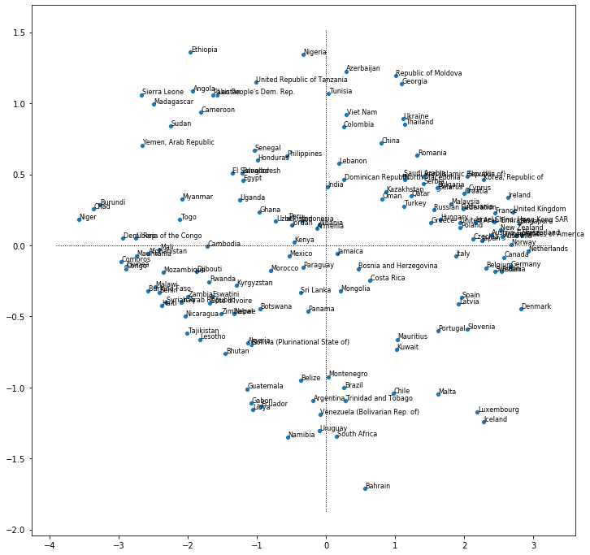

```python
# affichage des résultats
pays = df_ecom['Country']
x = -result.T[0]
y = -result.T[1]

# plot the figure
fig, ax = plt.subplots(figsize=(12, 12))

# scatterplot
sns.scatterplot(x=x, y=y, ax=ax)

# axes
ax.plot(plt.xlim(), [0.0, 0.0], ls=':', lw=1, color='k')
ax.plot([0.0, 0.0], plt.ylim(), ls=':', lw=1, color='k')

# labels
offset = 0.005
for label, x, y in zip(pays, x, y):
    ax.text(x+offset, y+offset, label, fontsize=8);
```

### Interprétation des résultats

La variable `explained_variance_ratio_` vaut le pourcentage de la variance expliquée par chacune des composantes. Les 2 facteurs expliquent 90% de la variance des données.

```python
# explained_variance_ratio_
pca.explained_variance_ratio_
```

```
array([0.8038732 , 0.09983894])
```

```python
# somme explained_variance_ratio_
pca.explained_variance_ratio_.sum()
```

```
0.9037121449912533
```

La variable `components_` vaut les axes principaux projetés dans l'espace des données.

```python
# components
pca.components_
```

```
array([[-0.50619063, -0.50485942, -0.52438183, -0.46250589],
       [ 0.21710545,  0.35193257,  0.2288724 , -0.88126393]])
```

```python
# on vérifie qu'ils sont orthogonaux
pca.components_[0]@pca.components_[1]  # ou pca.components_[0].dot(pca.components_[1])
```

```
-1.1102230246251565e-16
```

```python
# vérification avec allclose()
np.allclose(pca.components_[0]@pca.components_[1], 0.0)
```

```
True
```

```python
pca.components_[0]@pca.components_[0]  # ou pca.components_[0].dot(pca.components_[1])
```

```
1.0
```

```python
pca.components_[1]@pca.components_[1]  # ou pca.components_[0].dot(pca.components_[1])
```

```
0.9999999999999997
```

```python
np.allclose(pca.components_[1]@pca.components_[1], 1.0)  # ou pca.components_[0].dot(pca.components_[1])
```

```
True
```

Par ailleurs, comme la première composante est négative dans toutes les dimensions et que la plus grande valeur absolue de la seconde composante est négative, nous allons prendre les opposés des axes X et Y afin d'avoir une représentation plus standard : en bas à gauche les petites valeurs et en haut à droite les grandes valeurs.

### Scree plot

Il est également possible d'effectuer une ACP avec l'ensemble des composantes pour déterminer empiriquement le nombre de composantes à retenir avec la "cassure" formée dans un "scree plot".

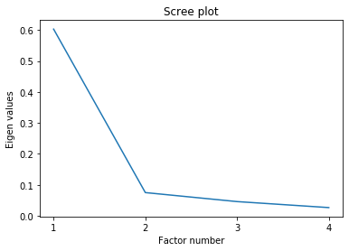

```python
# affichage de la variance expliquée en fonction des composantes
n = 4
pca = PCA(n_components=n)
result = pca.fit_transform(data_std)
eigenval = (n-1)/n * pca.explained_variance_ratio_
fig, ax = plt.subplots()
ax.plot(np.arange(n)+1, eigenval)
ax.set_title('Scree plot')
ax.set_xticks(range(1, 5))
ax.set_xlabel('Factor number')
ax.set_ylabel('Eigen values');
```

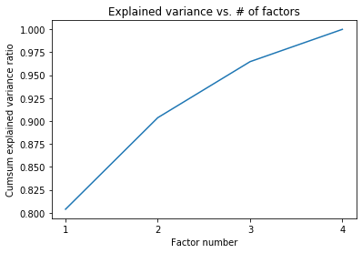

```python
# cumul de variance expliquée
fig, ax = plt.subplots()
ax.plot(np.arange(n)+1, np.cumsum(pca.explained_variance_ratio_))
ax.set_title("Explained variance vs. # of factors")
ax.set_xticks(range(1, 5))
ax.set_xlabel("Factor number")
ax.set_ylabel("Cumsum explained variance ratio");
```

### Amélioration du graphique

#### Dataset 2

Ajout des informations sur les pays : continent et population.

Source: https://www.geonames.org/countries/

```python
import os

# require internet access
if os.path.exists('GeoNames.htm'):
    var = pd.read_html('GeoNames.htm',
                       header=0,
                       encoding='latin-1',
                       keep_default_na=False)
else:
    var = pd.read_html('https://www.geonames.org/countries/',
                       header=0,
                       encoding='latin-1',
                       keep_default_na=False)

# display the shapes of the found tables
pays = var[1]
pays.head()
```

|  | ISO-3166alpha2 | ISO-3166alpha3 | ISO-3166numeric | fips | Country | Capital | Area in km² | Population | Continent |
| --- | --- | --- | --- | --- | --- | --- | --- | --- | --- |
| 0 | AD | AND | 20 | AN | Andorra | Andorra la Vella | 468.0 | 84000 | EU |
| 1 | AE | ARE | 784 | AE | United Arab Emirates | Abu Dhabi | 82880.0 | 4975593 | AS |
| 2 | AF | AFG | 4 | AF | Afghanistan | Kabul | 647500.0 | 29121286 | AS |
| 3 | AG | ATG | 28 | AC | Antigua and Barbuda | St. John's | 443.0 | 86754 | NA |
| 4 | AI | AIA | 660 | AV | Anguilla | The Valley | 102.0 | 13254 | NA |

On va effectuer une jointure entre les données de e-commerce et les pays pour pouvoir utiliser les informations de continent et de population. Faute de code ISO dans le fichier e-commerce, on va effectuer une jointure sur le nom des pays.

```python
# join with the Country dataset on the common `Country` column
df_ecom2 = pd.merge(df_ecom, pays, on='Country', how='inner')
df_ecom2.shape
```

```
(136, 13)
```

```python
df_ecom2.head()
```

|  | Country | Share of individuals using Internet (2017) | Share of individuals with an account (15+ 2017 or latest) | Secure Internet servers per 1 million people (normalized 2017) | UPU postal reliability score (2017) | ISO-3166alpha2 | ISO-3166alpha3 | ISO-3166numeric | fips | Capital | Area in km² | Population | Continent |
| --- | --- | --- | --- | --- | --- | --- | --- | --- | --- | --- | --- | --- | --- |
| 0 | Netherlands | 95 | 100 | 98 | 93 | NL | NLD | 528 | NL | Amsterdam | 41526.0 | 16645000 | EU |
| 1 | Switzerland | 94 | 98 | 95 | 95 | CH | CHE | 756 | SZ | Bern | 41290.0 | 8484100 | EU |
| 2 | Singapore | 88 | 98 | 97 | 97 | SG | SGP | 702 | SN | Singapore | 692.7 | 4701069 | AS |
| 3 | Finland | 94 | 100 | 90 | 94 | FI | FIN | 246 | FI | Helsinki | 337030.0 | 5244000 | EU |
| 4 | United Kingdom | 95 | 96 | 88 | 98 | GB | GBR | 826 | UK | London | 244820.0 | 62348447 | EU |

On remarque qu'il manque des pays...

```python
# pays absents
df_ecom.loc[~df_ecom['Country'].isin(df_ecom2['Country'].unique()), 'Country'].unique().tolist()
```

```
['United States of America',
 'China, Hong Kong SAR',
 'Korea, Republic of',
 'Russian Federation',
 'Iran (Islamic Republic of)',
 'Republic of Moldova',
 'Viet Nam',
 'Venezuela (Bolivarian Rep. of)',
 'United Republic of Tanzania',
 'Bolivia (Plurinational State of)',
 "Lao People's Dem. Rep.",
 "Cōte d'Ivoire",
 'Syrian Arab Republic',
 'Yemen, Arab Republic',
 'Congo',
 'Dem. Rep. of the Congo']
```

On effectue un mapping manuel des pays manquants.

```python
# mapping
mapping = {
    'United States of America': 'United States',
    'China, Hong Kong SAR': 'Hong Kong',
    'Korea, Republic of': 'North Korea',
    'Russian Federation': 'Russia',
    'Iran (Islamic Republic of)': 'Iran',
    'Republic of Moldova': 'Moldova',
    'Viet Nam': 'Vietnam',
    'Venezuela (Bolivarian Rep. of)': 'Venezuela',
    'United Republic of Tanzania': 'Tanzania',
    'Bolivia (Plurinational State of)': 'Bolivia',
    'Lao People\'s Dem. Rep.': 'Laos',
    'Cōte d\'Ivoire': 'Ivory Coast',
    'Syrian Arab Republic': 'Syria',
    'Yemen, Arab Republic': 'Yemen',
    'Congo': 'Congo Republic',
    'Dem. Rep. of the Congo': 'DR Congo'
}

df_ecom['Country'] = df_ecom['Country'].apply(lambda x: mapping.get(x, x))
df_ecom.head()
```

|  | Country | Share of individuals using Internet (2017) | Share of individuals with an account (15+ 2017 or latest) | Secure Internet servers per 1 million people (normalized 2017) | UPU postal reliability score (2017) |
| --- | --- | --- | --- | --- | --- |
| 0 | Netherlands | 95 | 100 | 98 | 93 |
| 1 | Switzerland | 94 | 98 | 95 | 95 |
| 2 | Singapore | 88 | 98 | 97 | 97 |
| 3 | Finland | 94 | 100 | 90 | 94 |
| 4 | United Kingdom | 95 | 96 | 88 | 98 |

On effectue à nouveau la jointure.

```python
# join with the Country dataset on the common `Country` column
df_ecom2 = pd.merge(df_ecom, pays, on='Country', how='inner')
df_ecom2.shape
```

```
(152, 13)
```

```python
# on vérie que tout colle
df_ecom['Country'].isin(df_ecom2['Country'].unique()).all()
```

```
True
```

On fusionne toutes les données nécessaires.

```python
# concatenate data
result2 = pd.concat([-pd.Series(result.T[0]),
                    -pd.Series(result.T[1]),
                    df_ecom2['Population'],
                    df_ecom2['Continent'],
                    df_ecom2['Country']],
                   axis=1)

result2 = result2.rename(columns={0:'x', 1:'y'})

# on trie par population décroissante afin que les grand cercles soient affichés en premier
result2 = result2.sort_values('Population', ascending=False)
result2.head()
```

|  | x | y | Population | Continent | Country |
| --- | --- | --- | --- | --- | --- |
| 55 | 0.799245 | 0.719412 | 1330044000 | AS | China |
| 72 | 0.017417 | 0.410016 | 1173108018 | AS | India |
| 12 | 2.541801 | 0.062288 | 310232863 | NA | United States |
| 83 | -0.350528 | 0.170947 | 242968342 | AS | Indonesia |
| 73 | 0.258460 | -1.002763 | 201103330 | SA | Brazil |

### Amélioration de l'affichage

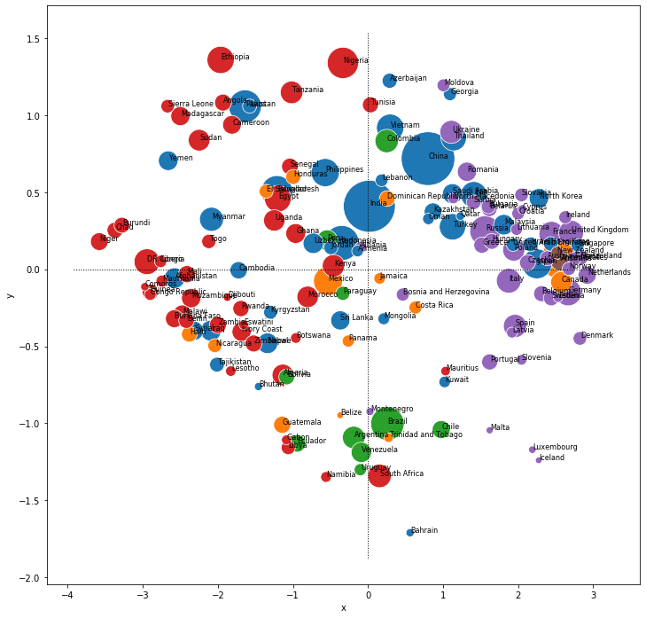

```python
# figure
fig, ax = plt.subplots(figsize=(12, 12))

# mapping des continents et des coleurs
c = result2['Continent']#.map({'AF': 'r', 'EU': 'b', 'AS': 'y', 'NA': 'c', 'SA': 'm', 'OC': 'g'})

# scatterplot
sns.scatterplot(x='x',
                y='y',
                data=result2,
                hue=c,
                s=np.sqrt(result2['Population'])/10,  # formule trouvée par tatonnement
                legend=False,
                ax=ax)

# axes
ax.plot(plt.xlim(), [0.0, 0.0], ls=':', lw=1, color='k')
ax.plot([0.0, 0.0], plt.ylim(), ls=':', lw=1, color='k')

# labels
offset = 0.005
for label, x, y in zip(result2['Country'], result2['x'], result2['y']):
    plt.text(x+offset, y+offset, label, fontsize=8);
```

```python
result2['Continent'].unique()
```

```
array(['AS', 'NA', 'SA', 'AF', 'EU', 'OC'], dtype=object)
```

## Idem avec t-SNE (t-distributed Stochastic Neighbor Embedding)

T-distributed Stochastic Neighbor Embedding (t-SNE) un algorithme de machine learning pour la visualisation.

Il s'agit d'une technique non-linéaire de réduction de dimension pour visualiser des données multi-dimensionnelles dans un espace à 2 ou 3 dimensions. Particulièrement, l'algorithme représente chaque objet par un point dans un espace à 2 ou 3 dimensions de sorte que des objets similaires sont représentés par des points proches et des objets non similaires par des points éloignés avec une forte probabilité.

**Exercise**

```python
TSNE?
```

```python
# import et application d'une TSNE
from sklearn.manifold import TSNE
tsne = TSNE(perplexity=10, random_state=1)
result = tsne.fit_transform(data_std)
```

```python
# concatenate data
result2 = pd.concat([pd.Series(result.T[0]),
                    pd.Series(result.T[1]),
                    df_ecom2['Population'],
                    df_ecom2['Continent'],
                    df_ecom2['Country']],
                   axis=1)

result2 = result2.rename(columns={0:'x', 1:'y'})

# on trie par population décroissante afin que les grand cercles soient affichés en premier
result2 = result2.sort_values('Population', ascending=False)
```

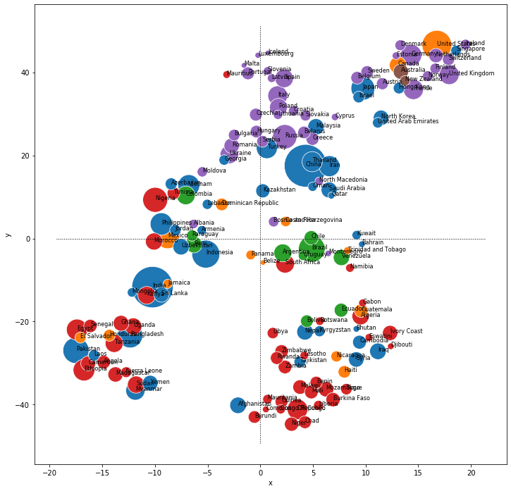

```python
# figure
fig, ax = plt.subplots(figsize=(12, 12))

# mapping des continents et des coleurs
c = result2['Continent']#.map({'AF': 'r', 'EU': 'b', 'AS': 'y', 'NA': 'c', 'SA': 'm', 'OC': 'g'})

# scatterplot
sns.scatterplot(x='x',
                y='y',
                data=result2,
                hue=c,
                s=np.sqrt(result2['Population'])/10,  # formule trouvée par tatonnement
                legend=False,
                ax=ax)

# axes
ax.plot(plt.xlim(), [0.0, 0.0], ls=':', lw=1, color='k')
ax.plot([0.0, 0.0], plt.ylim(), ls=':', lw=1, color='k')

# labels
offset = 0.005
for label, x, y in zip(result2['Country'], result2['x'], result2['y']):
    plt.text(x+offset, y+offset, label, fontsize=8);
```